# Group A

## Validation accuracy

```r
validation.accuracy.data <- all.data %>%
  filter(trial_type == 'webgazer-validate')
```

What % of subjects needed to recalibrate because of poor initial calibration?

```r
validation.accuracy.data %>%
  group_by(subject_id) %>%
  count() %>%
  group_by(n) %>%
  count()
```

```
Storing counts in `nn`, as `n` already present in input
i Use `name = "new_name"` to pick a new name.
```

| n | nn |
| --- | --- |
| 1 | 9 |
| 2 | 48 |

Get final average distance for each subject

```r
validation.percent <- validation.accuracy.data %>%
  group_by(subject_id) %>%
  slice_tail() %>%
  select(subject_id, percent_in_roi) %>%
  unnest(percent_in_roi) %>%
  group_by(subject_id) %>%
  summarise(M = mean(percent_in_roi), MAX = max(percent_in_roi), MIN = min(percent_in_roi)) %>%
  mutate(subject_id = fct_reorder(subject_id, M))
```

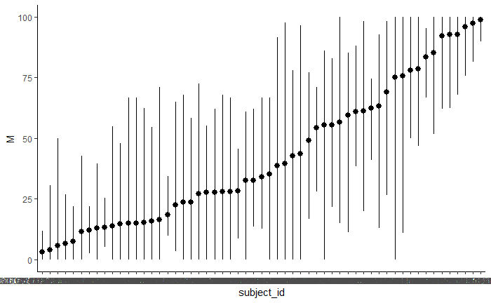

```r
ggplot(validation.percent, aes(x=subject_id, y=M, ymax = MAX, ymin=MIN))+
  geom_pointrange() +
  theme_classic()
```

Set criteria for minimal and aggressive exclusions

```r
if(exclusion.mode == 'AGGRESSIVE') {
  validation.threshold <- 50
}
if(exclusion.mode == 'MINIMAL') {
  validation.threshold <- 10
}

bad.subjects.validation <- validation.percent %>%
  filter(M <= validation.threshold) %>%
  pull(subject_id) %>%
  as.character()
```

## Final exclusion data

```r
bad.subjects <- unique(c(bad.subjects.prop.samples, bad.subjects.validation))

critical.trials.filtered <- critical.trials %>%
  filter(!subject_id %in% bad.subjects)
```

# Calculating cumulative fixation probability

We start by calculating cumulative fixation probability on the objects after the verb onset. (Any fixations prior to the verb onset are not relevant to the core research questions.)

First, add a column for time relative to verb onset, bin this to 50ms chunks, and filter the data to the 2,000 ms window after verb onset.

```r
cumulative.fixation.data <- critical.trials.filtered %>%
  mutate(t.relative.to.verb.onset = t - (verb_onset*1000)) %>%
  filter(t.relative.to.verb.onset >= 0 & t.relative.to.verb.onset <2000) %>%
  mutate(t.w = floor(t.relative.to.verb.onset/50)*50)
```

Now check every time window within a trial to account for sparse samples. This calculating is time consuming, so we cache the result in a CSV file, and load from the CSV if it already exists.

```r
cumulative.fixation.calculation <- function(df){
  time <- seq(0,1950,50)
  fixations <- logical(length(time))
  hit.flag <- FALSE
  for(i in 1:length(fixations)){
    if(hit.flag){
      fixations[i] <- TRUE
    } else {
      val <- df %>% filter(t.w <= time[i]) %>% pull(is.fixating) %>% any()
      if(val == TRUE) {
        hit.flag <- TRUE
      }
      fixations[i] <- val
    }
  }
  out <- tibble(t.window = time, has.fixated = fixations)
  return(out)
}

if(file.exists("data/generated/cumulative_fixation_data.csv")){
  cumulative.fixation.windows.data <- read_csv("data/generated/cumulative_fixation_data.csv")
} else {

  cumulative.fixation.windows.data <- cumulative.fixation.data %>%
    group_by(subject_id, verb_type, image_name, object_type, object_class) %>%
    summarize(cumulative.fixation.calculation(cur_data()))

  write_csv(cumulative.fixation.windows.data, path="data/generated/cumulative_fixation_data.csv")
}
```

Then group by object class to calculate fixation probability for each kind of object, normalizing by the number of objects of that type.

```r
cumulative.fixation.windows.grouped.data <- cumulative.fixation.windows.data %>%
  filter(!subject_id %in% bad.subjects) %>%
  group_by(subject_id, verb_type, image_name, object_class, t.window) %>%
  summarize(cumulative.fixation.p = mean(has.fixated))
```

Then collapse over trials to get a cumulative probability for the whole window for each subject

```r
cumulative.fixation.windows.grouped.average.data <- cumulative.fixation.windows.grouped.data %>%
  group_by(subject_id, verb_type, object_class, t.window) %>%
  summarize(cumulative.fixation.p = mean(cumulative.fixation.p))
```

Collapse across subjects to generate the equivalent of the figure from Altmann & Kamide.

```r
cumulative.fixation.data.summary <- cumulative.fixation.windows.grouped.average.data %>%
  filter(object_class %in% c('target.object', 'distractor')) %>%
  group_by(t.window, verb_type, object_class) %>%
  summarize(cumulative.fixation.m = mean(cumulative.fixation.p))
```

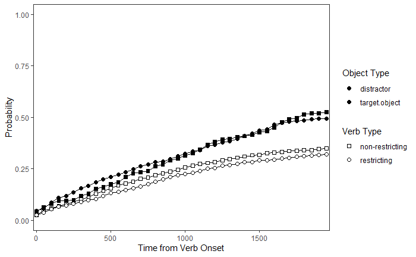

```r
ggplot(cumulative.fixation.data.summary, aes(x=t.window, y=cumulative.fixation.m, fill=object_class, shape=verb_type, group=interaction(verb_type, object_class)))+
  scale_fill_grey(start=1.0, end=0.0)+
  scale_shape_manual(values=c(22,21))+
  geom_line()+
  geom_point(size=2)+
  theme_bw()+
  theme(panel.grid=element_blank())+
  scale_y_continuous(limits=c(0,1))+
  scale_x_continuous(expand=c(0.01,0.01))+
  labs(x="Time from Verb Onset", y="Probability", shape="Verb Type", fill="Object Type")
```

# Question: Are there more pre-noun first looks to the target object than to the distractors?

First, grab the noun onset times to merge into our cumulative fixation data.

```r
noun.onset.times <- critical.trials.filtered %>%
  group_by(image_name, verb_type) %>%
  slice(1) %>%
  ungroup() %>%
  select(image_name, verb_type, delay_bw_onset_of_verb_and_onset_of_target_noun) %>%
  mutate(relative.noun.onset = delay_bw_onset_of_verb_and_onset_of_target_noun * 1000) %>%
  select(-delay_bw_onset_of_verb_and_onset_of_target_noun)

trial.level.cumulative.fixation.data <- cumulative.fixation.windows.grouped.data %>%
  left_join(noun.onset.times, by=c("image_name", "verb_type"))
```

Then, grab the last time window before the noun onset for each trial. This is the critical data for this test.

```r
pre.noun.first.looks.data <- trial.level.cumulative.fixation.data %>%
  group_by(subject_id, image_name, verb_type) %>%
  filter(t.window < relative.noun.onset) %>%
  filter(t.window == max(t.window)) %>%
  filter(object_class %in% c("target.object", "distractor"))
```

Fit the model, with no covariance between random effects because the model cannot converge with full covariance matrix.

```r
model <- afex::lmer_alt(cumulative.fixation.p ~ object_class * verb_type + (object_class * verb_type || image_name) + (object_class * verb_type || subject_id) , data=pre.noun.first.looks.data)
```

```
boundary (singular) fit: see ?isSingular
```

```r
summary(model)
```

```
Linear mixed model fit by REML. t-tests use Satterthwaite's method ['lmerModLmerTest']
Formula: cumulative.fixation.p ~ object_class * verb_type + (1 + re1.object_classtarget.object +
    re1.verb_typerestricting + re1.object_classtarget.object_by_verb_typerestricting ||
    image_name) + (1 + re2.object_classtarget.object + re2.verb_typerestricting +      re2.object_classtarget.object_by_verb_typerestricting ||
    subject_id)
   Data: data

REML criterion at convergence: 430.2

Scaled residuals:
    Min      1Q  Median      3Q     Max
-2.5430 -0.5898 -0.4124  0.4278  3.0210

Random effects:
 Groups       Name                                                  Variance  Std.Dev.
 subject_id   re2.object_classtarget.object_by_verb_typerestricting 4.432e-10 2.105e-05
 subject_id.1 re2.verb_typerestricting                              0.000e+00 0.000e+00
 subject_id.2 re2.object_classtarget.object                         1.078e-02 1.038e-01
 subject_id.3 (Intercept)                                           1.564e-03 3.955e-02
 image_name   re1.object_classtarget.object_by_verb_typerestricting 1.326e-02 1.152e-01
 image_name.1 re1.verb_typerestricting                              8.268e-04 2.875e-02
 image_name.2 re1.object_classtarget.object                         8.256e-03 9.086e-02
 image_name.3 (Intercept)                                           8.268e-04 2.875e-02
 Residual                                                           9.663e-02 3.109e-01
Number of obs: 704, groups:  subject_id, 22; image_name, 16

Fixed effects:
                                               Estimate Std. Error       df t value Pr(>|t|)
(Intercept)                                     0.18736    0.02594 33.38994   7.224 2.59e-08 ***
object_classtarget.object                       0.04117    0.04592 37.04245   0.897    0.376
verb_typerestricting                           -0.03126    0.03397 37.74021  -0.920    0.363
object_classtarget.object:verb_typerestricting  0.06772    0.05516 33.39775   1.228    0.228
---
Signif. codes:  0 ‘***’ 0.001 ‘**’ 0.01 ‘*’ 0.05 ‘.’ 0.1 ‘ ’ 1

Correlation of Fixed Effects:
            (Intr) objc_. vrb_ty
objct_clss. -0.461
vrb_typrstr -0.625  0.353
objct_cl.:_  0.385 -0.436 -0.588
convergence code: 0
boundary (singular) fit: see ?isSingular
```

# Question: Are there more pre-verb-offset first looks to the target object than to the distractors?

Verb offset times

```r
verb.offset.times <- critical.trials.filtered %>%
  group_by(image_name, verb_type) %>%
  slice(1) %>%
  ungroup() %>%
  select(image_name, verb_type, duration_of_verb) %>%
  mutate(relative.verb.offset = duration_of_verb * 1000) %>%
  select(-duration_of_verb)

trial.level.cumulative.fixation.data.verb.offset <- cumulative.fixation.windows.grouped.data %>%
  left_join(verb.offset.times, by=c("image_name", "verb_type"))
```

```r
pre.verb.offset.first.looks.data <- trial.level.cumulative.fixation.data.verb.offset %>%
  group_by(subject_id, image_name, verb_type) %>%
  filter(t.window < relative.verb.offset) %>%
  filter(t.window == max(t.window)) %>%
  filter(object_class %in% c("target.object", "distractor"))
```

```r
model <- lmer_alt(cumulative.fixation.p ~ object_class * verb_type + (object_class * verb_type || image_name) + (object_class * verb_type || subject_id) , data=pre.verb.offset.first.looks.data)
```

```
boundary (singular) fit: see ?isSingular
```

```r
summary(model)
```

```
Linear mixed model fit by REML. t-tests use Satterthwaite's method ['lmerModLmerTest']
Formula: cumulative.fixation.p ~ object_class * verb_type + (1 + re1.object_classtarget.object +
    re1.verb_typerestricting + re1.object_classtarget.object_by_verb_typerestricting ||
    image_name) + (1 + re2.object_classtarget.object + re2.verb_typerestricting +      re2.object_classtarget.object_by_verb_typerestricting ||
    subject_id)
   Data: data

REML criterion at convergence: 242.9

Scaled residuals:
    Min      1Q  Median      3Q     Max
-1.7111 -0.5050 -0.3577  0.3676  3.3077

Random effects:
 Groups       Name                                                  Variance  Std.Dev.
 subject_id   re2.object_classtarget.object_by_verb_typerestricting 0.0064073 0.08005
 subject_id.1 re2.verb_typerestricting                              0.0000000 0.00000
 subject_id.2 re2.object_classtarget.object                         0.0086089 0.09278
 subject_id.3 (Intercept)                                           0.0002087 0.01445
 image_name   re1.object_classtarget.object_by_verb_typerestricting 0.0046544 0.06822
 image_name.1 re1.verb_typerestricting                              0.0005157 0.02271
 image_name.2 re1.object_classtarget.object                         0.0032684 0.05717
 image_name.3 (Intercept)                                           0.0021912 0.04681
 Residual                                                           0.0739586 0.27195
Number of obs: 704, groups:  subject_id, 22; image_name, 16

Fixed effects:
                                               Estimate Std. Error       df t value Pr(>|t|)
(Intercept)                                     0.13874    0.02383 34.71274   5.821 1.37e-06 ***
object_classtarget.object                       0.01555    0.03793 34.95839   0.410    0.684
verb_typerestricting                           -0.02709    0.02964 50.93692  -0.914    0.365
object_classtarget.object:verb_typerestricting  0.05201    0.04769 43.64059   1.091    0.281
---
Signif. codes:  0 ‘***’ 0.001 ‘**’ 0.01 ‘*’ 0.05 ‘.’ 0.1 ‘ ’ 1

Correlation of Fixed Effects:
            (Intr) objc_. vrb_ty
objct_clss. -0.466
vrb_typrstr -0.599  0.375
objct_cl.:_  0.371 -0.467 -0.597
convergence code: 0
boundary (singular) fit: see ?isSingular
```

# Do people look at the target faster after a restricting verb

```r
first.fixation.after.verb.onset <- critical.trials.filtered %>%
  group_by(subject_id, image_name) %>%
  filter(t >= verb_onset*1000) %>%
  filter(object_type == "target.object") %>%
  filter(is.fixating == TRUE) %>%
  filter(t == min(t)) %>%
  mutate(relative.t = t - (postverbal_noun_onset*1000))
```

```r
first.fixation.after.verb.onset.analysis.data <- first.fixation.after.verb.onset %>%
  ungroup() %>%
  select(subject_id, image_name, verb_type, relative.t)
```

```r
model <- lmer_alt(relative.t ~ verb_type + (verb_type || subject_id) + (verb_type || image_name), data=first.fixation.after.verb.onset.analysis.data)
```

```
boundary (singular) fit: see ?isSingular
```

```r
summary(model)
```

```
Linear mixed model fit by REML. t-tests use Satterthwaite's method ['lmerModLmerTest']
Formula: relative.t ~ verb_type + (1 + re1.verb_typerestricting || subject_id) +      (1 + re2.verb_typerestricting || image_name)
   Data: data

REML criterion at convergence: 3713.1

Scaled residuals:
    Min      1Q  Median      3Q     Max
-1.7694 -0.7085 -0.1222  0.6077  4.5254

Random effects:
 Groups       Name                     Variance  Std.Dev.
 subject_id   (Intercept)              2.916e+04 170.7583
 subject_id.1 re1.verb_typerestricting 0.000e+00   0.0000
 image_name   (Intercept)              3.174e+04 178.1580
 image_name.1 re2.verb_typerestricting 1.323e-04   0.0115
 Residual                              4.936e+05 702.5511
Number of obs: 233, groups:  subject_id, 22; image_name, 16

Fixed effects:
                     Estimate Std. Error      df t value Pr(>|t|)
(Intercept)            479.42      86.36   33.26   5.551 3.53e-06 ***
verb_typerestricting  -172.08      94.41  217.12  -1.823   0.0697 .
---
Signif. codes:  0 ‘***’ 0.001 ‘**’ 0.01 ‘*’ 0.05 ‘.’ 0.1 ‘ ’ 1

Correlation of Fixed Effects:
            (Intr)
vrb_typrstr -0.507
convergence code: 0
boundary (singular) fit: see ?isSingular
```

```r
first.fixation.after.verb.onset.subject.summary <- first.fixation.after.verb.onset %>%
  group_by(subject_id, verb_type) %>%
  summarize(m.t = mean(relative.t), ct = n())
first.fixation.after.verb.onset.summary <- first.fixation.after.verb.onset.subject.summary %>%
  group_by(verb_type) %>%
  summarize(m=mean(m.t), sd=sd(m.t), se=sd/sqrt(n()))
```

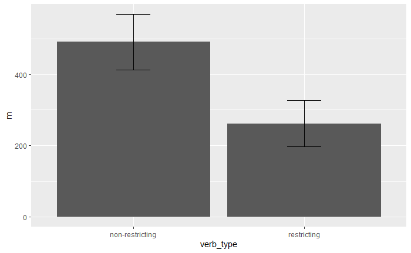

```r
ggplot(first.fixation.after.verb.onset.summary, aes(x=verb_type, y=m, ymin=m-se,ymax=m+se))+
  geom_col()+
  geom_errorbar(width=0.2)
```